# Skilled Nursing Facilities

#### Trending Staffing Ratios

Reported staffing ratios vary each year, noticeably spiking in 2020 during the height of the delta wave. Per advisers, this is due to a converted effort by health systems to divert lower acuity patients to the home setting in order to reduce the infection risk. The data do not appear normally distributed, exhibiting a positive skew.

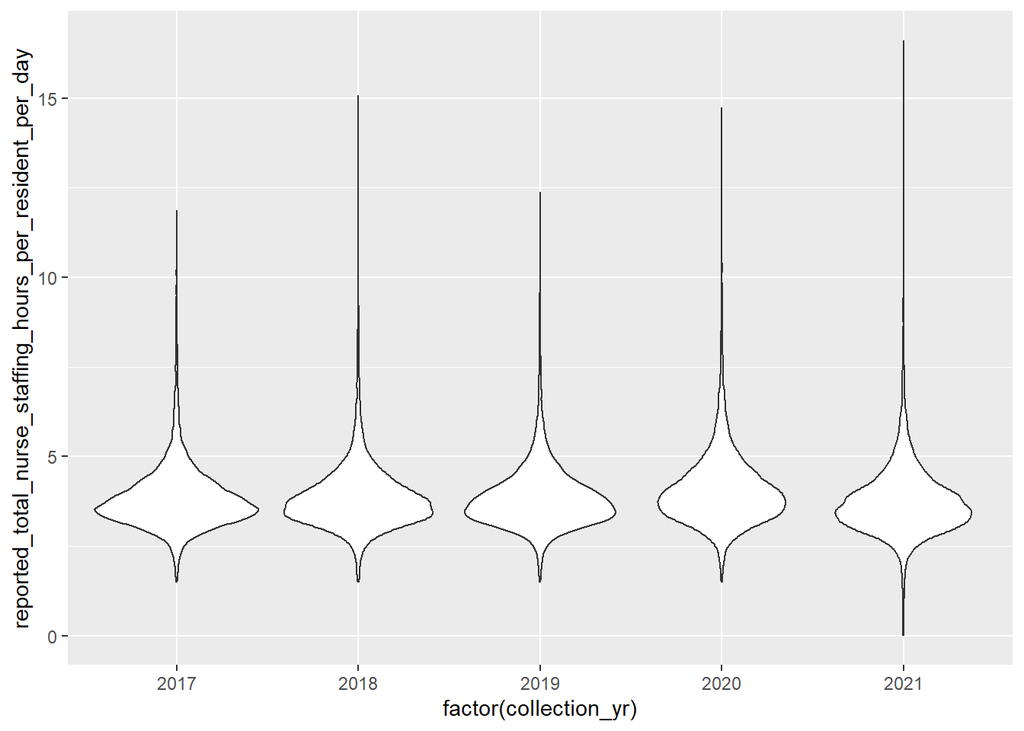

```r
ggplot(data = q4_snf_data, aes(factor(collection_yr), reported_total_nurse_staffing_hours_per_resident_per_day)) + geom_violin()
```

The spike in staffing ratios and corresponding drop in average daily residents are visible in below table. Confusingly, the case mix variable does not corroborate increased acuity. It decreases in 2020 and 2021.

```r
select(q4_snf_data,
      c("collection_yr", "reported_total_nurse_staffing_hours_per_resident_per_day","adjusted_total_nurse_staffing_hours_per_resident_per_day","case-mix_total_nurse_staffing_hours_per_resident_per_day","average_number_of_residents_per_day","provider_changed_ownership_in_last_12_months")) %>% rename(yr = collection_yr, reported_staff_prpd = reported_total_nurse_staffing_hours_per_resident_per_day, adjusted_staff_prpd = adjusted_total_nurse_staffing_hours_per_resident_per_day, case_mix = `case-mix_total_nurse_staffing_hours_per_resident_per_day`, avg_rpd = average_number_of_residents_per_day, chow = provider_changed_ownership_in_last_12_months) %>%
  tbl_summary(by=yr)
```

| **Characteristic** | **2017**, N = 15,623<sup>1</sup> | **2018**, N = 15,552<sup>1</sup> | **2019**, N = 15,425<sup>1</sup> | **2020**, N = 15,318<sup>1</sup> | **2021**, N = 15,193<sup>1</sup> |
| --- | --- | --- | --- | --- | --- |
| reported_staff_prpd | 3.68 (3.32, 4.20) | 3.72 (3.31, 4.22) | 3.70 (3.30, 4.20) | 3.90 (3.44, 4.50) | 3.61 (3.17, 4.15) |
| Unknown | 1,503 | 711 | 561 | 678 | 653 |
| adjusted_staff_prpd | 3.72 (3.32, 4.23) | 3.75 (3.31, 4.27) | 3.75 (3.30, 4.26) | 3.94 (3.43, 4.57) | 3.65 (3.15, 4.24) |
| Unknown | 1,593 | 769 | 611 | 769 | 743 |
| case_mix | 3.22 (3.04, 3.40) | 3.20 (3.01, 3.38) | 3.20 (3.01, 3.38) | 3.18 (3.01, 3.37) | 3.14 (2.96, 3.32) |
| Unknown | 1,520 | 711 | 577 | 678 | 653 |
| avg_rpd | 79 (52, 108) | 78 (51, 108) | 78 (51, 108) | 67 (44, 91) | 69 (46, 96) |
| Unknown | 803 | 61 | 69 | 77 | 64 |
| chow |  |  |  |  |  |
| N | 15,127 (97%) | 15,167 (98%) | 15,019 (97%) | 15,098 (99%) | 14,940 (98%) |
| Y | 496 (3.2%) | 385 (2.5%) | 406 (2.6%) | 220 (1.4%) | 253 (1.7%) |

<sup>1</sup> Median (IQR); n (%)

Since my main explanatory variable, accountable care penetration is not observed at the facility level, I aggregate staffing ratios to the county level for symmetry. Dr. Hsu indicated that variables from high level dimensions are often included as fixed effects, but not the primary variable of interest. As an example, census tract level social determinants of health are often projected to the individual level. However, these are typically used as controls, rather than the primary variable of interest.

```r
library(tidyr)
group_cols <- c("FIPS_Code", "StateAbbrev", "StdCountyName", "collection_yr")

q4_snf_data <- q4_snf_data %>% rename(case_mix_total_nurse_prpd = `case-mix_total_nurse_staffing_hours_per_resident_per_day`,
case_mix_cna_prpd = `case-mix_nurse_aide_staffing_hours_per_resident_per_day`,
case_mix_rn_prpd = `case-mix_rn_staffing_hours_per_resident_per_day`,
chow = provider_changed_ownership_in_last_12_months)
county_staffing <- q4_snf_data %>%
  group_by(across(all_of(group_cols))) %>%
  summarize(
    row_cnt = n(),
    cerfied_beds = sum(number_of_certified_beds, na.rm=TRUE),
    sum_avg_daily_residents = sum(average_number_of_residents_per_day, na.rm=TRUE),
    mean_cna_reported_hprd = weighted.mean(reported_nurse_aide_staffing_hours_per_resident_per_day, average_number_of_residents_per_day, na.rm=TRUE),
    mean_lpn_reported_hprd = weighted.mean(reported_lpn_staffing_hours_per_resident_per_day, average_number_of_residents_per_day, na.rm=TRUE),
    mean_rn_reported_hprd = weighted.mean(reported_rn_staffing_hours_per_resident_per_day, average_number_of_residents_per_day, na.rm=TRUE),
    mean_licensed_reported_hprd = weighted.mean(reported_licensed_staffing_hours_per_resident_per_day, average_number_of_residents_per_day, na.rm=TRUE),
    mean_total_reported_hprd = weighted.mean(reported_total_nurse_staffing_hours_per_resident_per_day, average_number_of_residents_per_day, na.rm=TRUE),
    mean_total_cm_hprd = weighted.mean(case_mix_total_nurse_prpd, average_number_of_residents_per_day, na.rm=TRUE),
    mean_cna_cm_hprd = weighted.mean(case_mix_cna_prpd, average_number_of_residents_per_day, na.rm=TRUE),
    mean_rn_cm_hprd = weighted.mean(case_mix_rn_prpd, average_number_of_residents_per_day, na.rm=TRUE)
)

save(county_staffing, file=here("data", "interim", "county_level_staffing.Rda"))
save(q4_snf_data, file=here("data", "interim", "snf_provider_info.Rda"))
```

Merge MA and ACO enrollment data to create the explanatory variables.

*One important note on this data-set.* In both the Medicare enrollment by county file and the ACO enrollment file, CMS does not provide a specific value when enrollee count is less than 10 in a given year. This is an effort to protect the privacy of members. Unfortunately, this obfuscation effectively zeros out accountable care penetration for the least populous counties, which tend to be rural. Without a member level dataset, I cannot address this issue.

```r
library(stringr)
aco_enroll <- read_delim(here("data", "interim", "aco_enrollment.csv"),
     delim = "|", escape_double = FALSE, trim_ws = TRUE) # created by `transform/aco_beneficiaries_by_county.py`
med_enroll <- read_delim(here("data", "interim", "medicare_enrollment.csv"),
     delim = "|", escape_double = FALSE, trim_ws = TRUE) # created by  `transform/medicare_benes_by_county.py`
med_enroll <- rename(med_enroll, Year = YEAR)
```

Some data cleaning required to merge counties. Overall, great correspondence when using FIPS code to merge.

```r
aco_enroll[is.na(aco_enroll$Tot_AB_Psn_Yrs), "Tot_AB_Psn_Yrs"] <- 0

# Group aco data to the county level
aco_by_county <- aco_enroll %>%
  group_by(FIPS_Code, Year) %>%
  summarize(ACOBenePsnYrs = sum(Tot_AB_Psn_Yrs))

pene_df <- merge(
  med_enroll,
  aco_by_county,
  by=c("FIPS_Code", "Year"),
  all.x = TRUE
)
pene_df <- rename(
  pene_df,
  AllMedBenePsnYrs = TOT_BENES,
  OrigMedBenePsnYrs = ORGNL_MDCR_BENES,
  MA_BenePsnYrs = MA_AND_OTH_BENES,
)
pene_df <- select(
  pene_df,
  c("FIPS_Code","StateAbbrev", "Year", "AllMedBenePsnYrs", "OrigMedBenePsnYrs", "MA_BenePsnYrs", "ACOBenePsnYrs")
)

# filter out obs where total medicare enroll is unknown. This denominator is required to compute penetration figure.
print(count(pene_df))
```

```
##       n
## 1 16378
```

```r
pene_df <- filter(
  pene_df,
  !is.na(pene_df$AllMedBenePsnYrs)
)

# assume if there is no ACO record, that there were no assigned enrollees
pene_df[is.na(pene_df$ACOBenePsnYrs), "ACOBenePsnYrs"] <- 0
```

Calculate accountable care penetration figures by county and year

```r
pene_df <- pene_df %>%
  mutate(ACOPenetration = ACOBenePsnYrs / AllMedBenePsnYrs) %>%
  mutate(MAPenetration = MA_BenePsnYrs / AllMedBenePsnYrs) %>%
  mutate(AccountableCarePenetration = MAPenetration + ACOPenetration) %>%
  mutate(LogAllMedBenePsnYrs = log(AllMedBenePsnYrs))
```

There appears to be a positive relationship between accountable care penetration and the size of the county. This may be introduced by our obfuscated data issue described above. In 2019, there are also penetration values above 1, which should not be possible, given that MA and ACO enrollees are drawn from the set of total medicare beneficiaries. This issue appears to affect 63 counties, solely in 2019.

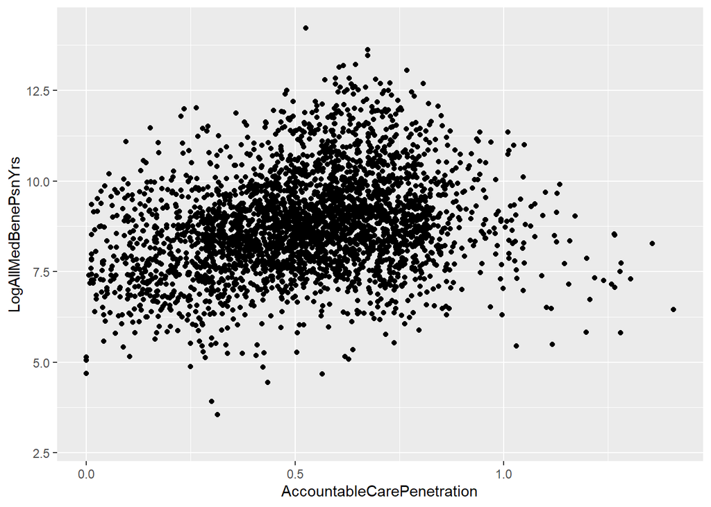

```r
plt <- ggplot(filter(pene_df, Year == 2019), mapping=aes(x=AccountableCarePenetration, y=LogAllMedBenePsnYrs)) +
  geom_point()
plt
```

```r
# 63 observations in 2019
unique(filter(pene_df, AccountableCarePenetration > 1)$Year)
```

```
## [1] 2019
```

Calculated MA penetration figures are corroborated by KFF Report, consistently 1-2% below. Not perfect, but good enough.

```r
pene_df %>%
  group_by(Year) %>%
  summarize(ma_sum = sum(MA_BenePsnYrs, na.rm = TRUE), med_sum = sum(AllMedBenePsnYrs),
            pene = sum(MA_BenePsnYrs, na.rm=TRUE) / sum(AllMedBenePsnYrs, na.rm=TRUE))
```

```
## # A tibble: 5 × 4
##    Year   ma_sum  med_sum  pene
##   <dbl>    <dbl>    <dbl> <dbl>
## 1  2017 19784141 57977580 0.341
## 2  2018 21320702 59502786 0.358
## 3  2019 22933446 61012499 0.376
## 4  2020 25059209 62320991 0.402
## 5  2021 27531024 63376332 0.434
```

```r
county_pene <- pene_df
rm(pene_df)
save(county_pene, file=here("data", "interim", "county_vbc_penetration.Rda"))
```

```r
load(here("data", "interim", "county_vbc_penetration.Rda"))
load(here("data", "interim", "county_level_staffing.Rda"))

county_staffing <- rename(
  county_staffing,
  Year = collection_yr
)

merged <- merge(
  county_pene,
  county_staffing,
  by=c("FIPS_Code", "Year"),
  all.x = TRUE
)

# multiply pene figures by 100 to ease interpretation
merged$AccountableCarePenetration = merged$AccountableCarePenetration * 100
merged$MAPenetration = merged$MAPenetration * 100
merged$ACOPenetration = merged$ACOPenetration * 100
merged$YearFactor = as.factor(merged$Year)
```

Visualizing all years, the 2019 strangeness for Accountable Care Penetration is apparent. There is significantly higher dispersion for this observation. Could this be due to ACO dropout at high rate in 2019? Skewed small ACO’s, unaffliated with health system.

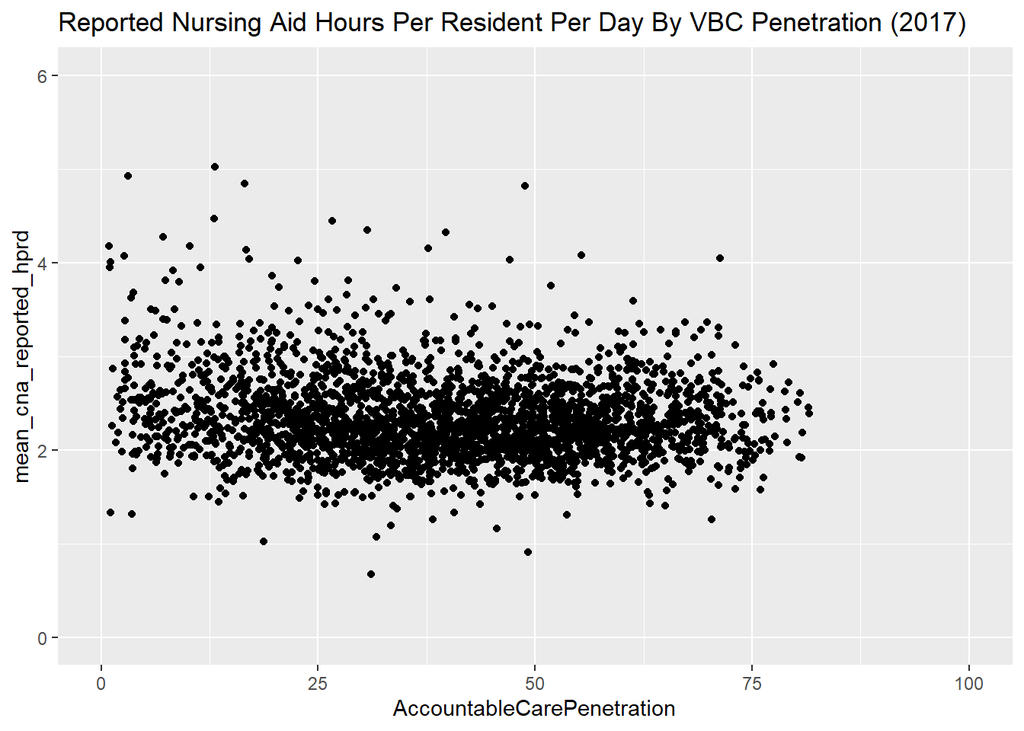

```r
plt <- ggplot(filter(merged, Year == 2017), mapping=aes(x = AccountableCarePenetration, y = mean_cna_reported_hprd)) + geom_point() + xlim(0,100) + ylim(0,6) + ggtitle(label="Reported Nursing Aid Hours Per Resident Per Day By VBC Penetration (2017)")
plt
```

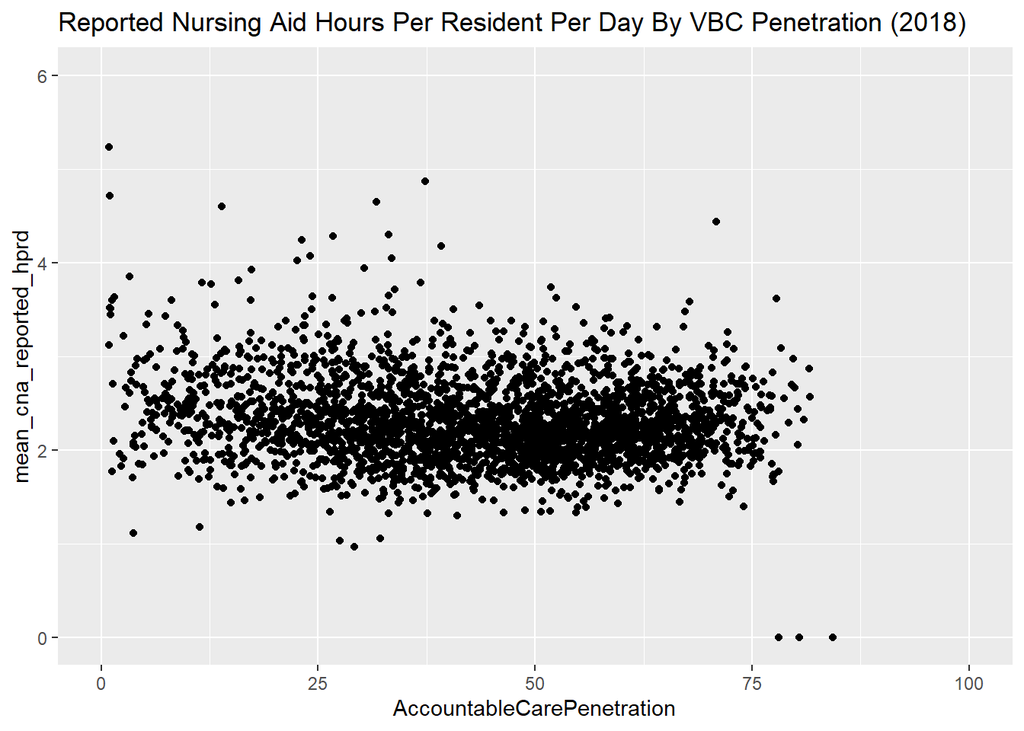

```r
plt <- ggplot(filter(merged, Year == 2018), mapping=aes(x = AccountableCarePenetration, y = mean_cna_reported_hprd)) + geom_point()  + xlim(0,100) + ylim(0,6) + ggtitle(label="Reported Nursing Aid Hours Per Resident Per Day By VBC Penetration (2018)")
plt
```

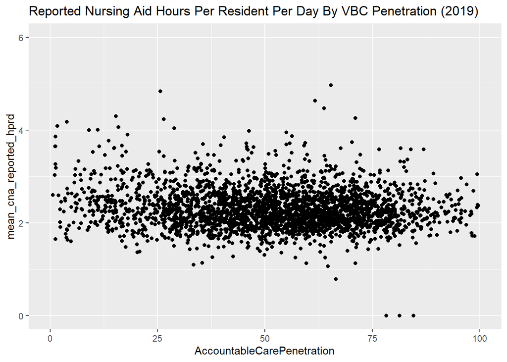

```r
plt <- ggplot(filter(merged, Year == 2019), mapping=aes(x = AccountableCarePenetration, y = mean_cna_reported_hprd)) + geom_point()  + xlim(0,100) + ylim(0,6) + ggtitle(label="Reported Nursing Aid Hours Per Resident Per Day By VBC Penetration (2019)")
plt
```

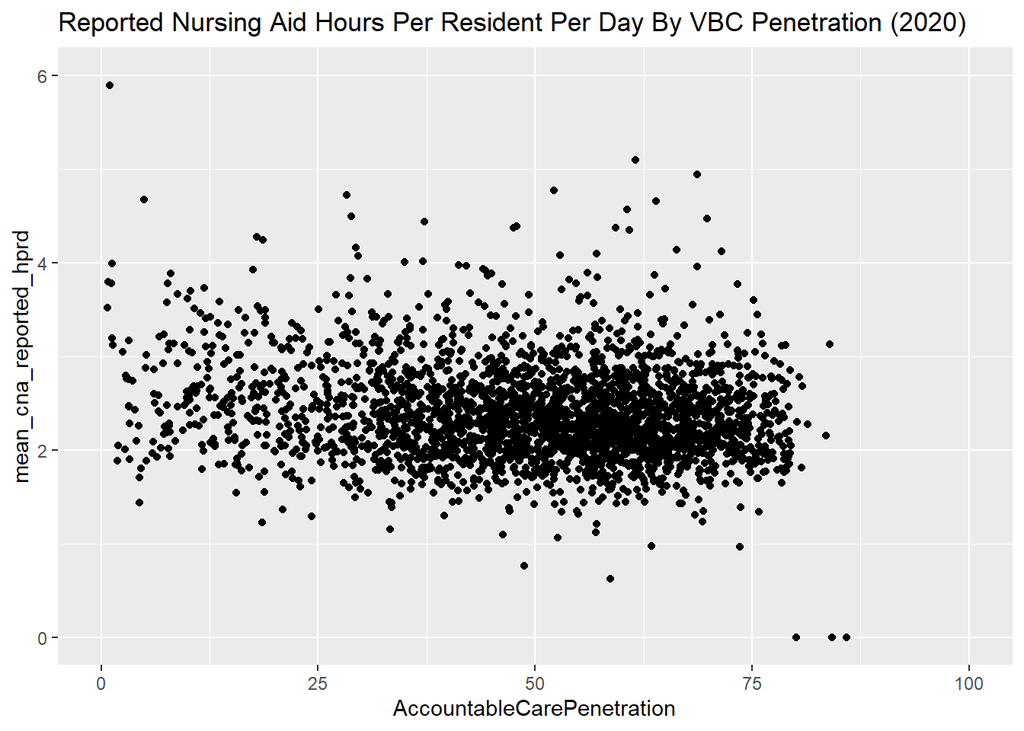

```r
plt <- ggplot(filter(merged, Year == 2020), mapping=aes(x = AccountableCarePenetration, y = mean_cna_reported_hprd)) + geom_point()  + xlim(0,100) + ylim(0,6)+ ggtitle(label="Reported Nursing Aid Hours Per Resident Per Day By VBC Penetration (2020)")
plt
```

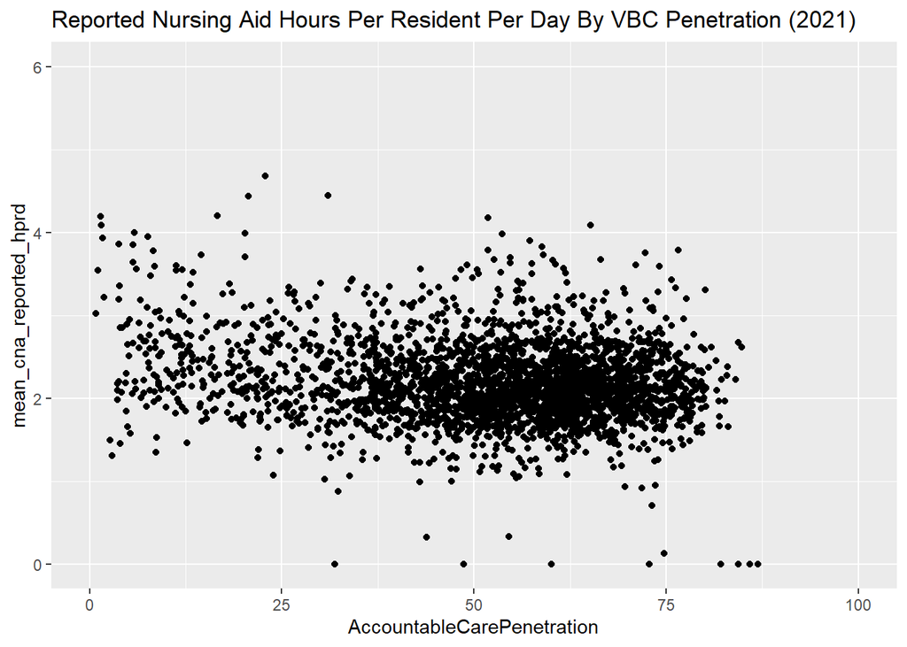

```r
plt <- ggplot(filter(merged, Year == 2021), mapping=aes(x = AccountableCarePenetration, y = mean_cna_reported_hprd)) + geom_point() + xlim(0,100) + ylim(0,6) + ggtitle(label="Reported Nursing Aid Hours Per Resident Per Day By VBC Penetration (2021)")
plt
```

How to explain the spike in VBC penetration in 2019? Something appears to be wrong with the data… Seeing rates >1

[Drop in ACO’s in 2019](https://www.naacos.com/press-release--medicare-aco-participation-flat-in-2022). * So why would pene increase in this year? * Dropout due to 5 year contracts, enforcing down-risk for some organizations.

## Results

```r
options(max.print=30) # omit distracting fixed effects
model <- lm(mean_total_reported_hprd ~ MAPenetration + ACOPenetration + StateAbbrev.x:YearFactor + mean_total_cm_hprd, merged)
print(summary(model))
```

```
##
## Call:
## lm(formula = mean_total_reported_hprd ~ MAPenetration + ACOPenetration +
##     StateAbbrev.x:YearFactor + mean_total_cm_hprd, data = merged)
##
## Residuals:
##     Min      1Q  Median      3Q     Max
## -3.8566 -0.2726 -0.0272  0.2283  6.4856
##
## Coefficients: (2 not defined because of singularities)
##                                  Estimate Std. Error t value Pr(>|t|)
## (Intercept)                     2.738e+00  1.351e-01  20.273  < 2e-16 ***
## MAPenetration                  -2.813e-03  4.506e-04  -6.243 4.43e-10 ***
## ACOPenetration                  8.461e-05  3.200e-04   0.264 0.791474
## mean_total_cm_hprd              3.525e-01  2.760e-02  12.772  < 2e-16 ***
## StateAbbrev.xAK:YearFactor2017  2.905e+00  2.742e-01  10.595  < 2e-16 ***
## StateAbbrev.xAL:YearFactor2017  3.362e-01  1.249e-01   2.692 0.007106 **
##  [ reached getOption("max.print") -- omitted 258 rows ]
## ---
## Signif. codes:  0 '***' 0.001 '**' 0.01 '*' 0.05 '.' 0.1 ' ' 1
##
## Residual standard error: 0.5044 on 13807 degrees of freedom
##   (2039 observations deleted due to missingness)
## Multiple R-squared:  0.3584, Adjusted R-squared:  0.3463
## F-statistic: 29.55 on 261 and 13807 DF,  p-value: < 2.2e-16
```

```r
print(-2.813e-03 * 60 * 60) # second reduction
```

```
## [1] -10.1268
```

```r
#model <- lm(mean_cna_reported_hprd ~ MAPenetration + ACOPenetration + StateAbbrev.x:YearFactor + mean_cna_cm_hprd, merged)
#print(summary(model))

#model <- lm(mean_cna_reported_hprd ~ MAPenetration + ACOPenetration + StateAbbrev.x:YearFactor + mean_cna_cm_hprd, #filter(merged, YearFactor != 2019))
#print(summary(model))

#model <- lm(mean_rn_reported_hprd ~ MAPenetration + ACOPenetration + StateAbbrev.x:YearFactor + mean_rn_cm_hprd, merged)
#print(summary(model))

# county level fixed effects - did not produce any useful output due to singularities
#model <- lm(mean_cna_reported_hprd ~ MAPenetration + ACOPenetration + FIPS_Code:YearFactor + mean_cna_cm_hprd, merged)
#print(summary(model))
```

In addition, I have also omitted important controls which are unavailable in public datasets. Notably, Atul et al. include controls for the proportion of residents with Medicaid coverage, as well as metrics to represent market dynamics, including SNF concentration within a given hospital referral region. I would expect Medicaid coverage in particular to confound the relationship between MA penetration and staffing ratios.

[figure not shown]

What counter-balancing forces may contribute to this outcome?

- The water balloon effect. SNF’s receiving pressure in Part A space may respond by increasing services in Part B.
- Some SNF’s receive financial supports via integration in larger system. For instance, a SNF onsite at a continuing care retirement community, or owned by a hospital may be better equipped in negotiation with MA health plans.
- SNF contracting with MA health plans may be supportive in some respects. Depending on contract parameters, it may bring revenue predictability that a fee for service arrangement does not.
- ACO’s exert very little direct influence over SNF operations. They simply do not have many levers to pull in order to affect behavior. This outcome contradicts portrayals of SNF’s as the “ACO piggybank”.
- Accountable care penetration might increase concentration of referrals. This could adversely affect some SNF’s, but support others, resulting in a neutral aggregate impact.

# Part 2

## Introduction

In this part, I investigate claims in a [2021 NyTimes article](https://www.nytimes.com/2021/03/13/business/nursing-homes-ratings-medicare-covid.html) that some SNF’s have padded their public star ratings by exploiting a nuance in staffing ratio calculations. Specifically, nursing staff “with administrative duties” may be counted alongside direct care nursing staff in calculating staffing ratios. As an example, per the CMS data payroll submission manual, an “LPN with administrative duties” is defined as: ““” …other nurses whose principal duties are spent conducting administrative functions. For example, the LPN Charge Nurse is conducting educational/in-service, or other duties which are not considered to be direct care giving. ““”

Such a nurse may engage in direct resident care, as long as it’s not their “principal duties”. *Or, they might sit at the front desk and fill out paperwork for their entire shift.* The category is unfortunately ambiguous.

## Methods

To assess whether nursing homes use “admin duties” to pad their quality scores, I used publically available, daily [payroll-based staffing journals](https://data.cms.gov/quality-of-care/payroll-based-journal-daily-nurse-staffing) submitted to CMS. I then construct an “administrative intensity” metric as the percentage of total nursing hours which are reported “with admin duties”. Finally, using a case / control design, I use logistic regression to model if a large year-over-year change in admin intensity is predictive of year-over-year staffing rate increases.

*Case Definition* I define a case as a nursing home with a year-over-year (YOY) change in staffing star rating from <4 to >= 4. This reflects my assumption that shenanigan-prone facilities might play games with CMS’s overall star rating methodology. Specifically, in the time period studied (2017-2021), a facility with >= 4 staffing rating received a +1 star increase to their overall star rating. As an example, the facility described in the Nytimes article, Sun Terrace in FL (CCN = 105319), increased their staffing star rating from 2->5 between 2017 and 2018, which yielded an extra star in their overall star rating. This increase coincided with a 18 pct point increase in admin intensity, from 6% to 24%.

*Control Definition* Controls are all yoy observations which: 1. Do not fit the case definition 2. Have complete year over year observations for both daily payroll based admin intensity and publically reported staffing ratios. Note, when a facility misses or incorrectly reports staffing data, their staffing rating drops to 1. I have ommitted these observations because it implies that CMS rejected the data I use to calculate administrative intensity.

```r
load(here("data", "interim", "snf_provider_info.Rda"))
pbj <- read.csv(here("data", "interim", "pbj_facility_level.csv"))
```

Create YOY staffing ratios and quality star changes using existing dataset and add the case definition.

```r
staffing_next_yr <- select(q4_snf_data, c("federal_provider_number", "staffing_rating", "collection_yr", "adjusted_rn_staffing_hours_per_resident_per_day", "adjusted_total_nurse_staffing_hours_per_resident_per_day", "ownership_type", "average_number_of_residents_per_day", "chow", "continuing_care_retirement_community","average_number_of_residents_per_day",
"overall_rating", "health_inspection_rating", "qm_rating"))
staffing_next_yr$collection_yr = staffing_next_yr$collection_yr - 1

# left join assigns x and y to shared column names
# x suffix = y1
# y suffix = y2
snf_level_data <- q4_snf_data %>%
  left_join(staffing_next_yr, by=c("federal_provider_number", "collection_yr"))
staffing_yoy <- select(snf_level_data,
    c("federal_provider_number", "staffing_rating.x", "collection_yr",
       "staffing_rating.y","adjusted_rn_staffing_hours_per_resident_per_day.x", "adjusted_total_nurse_staffing_hours_per_resident_per_day.x",
      "adjusted_rn_staffing_hours_per_resident_per_day.y", "adjusted_total_nurse_staffing_hours_per_resident_per_day.y",
      "ownership_type.x", "ownership_type.y", "average_number_of_residents_per_day.x",
      "average_number_of_residents_per_day.y",
      "chow.y", "continuing_care_retirement_community.y",
      "average_number_of_residents_per_day.x", "average_number_of_residents_per_day.y",
      "overall_rating.x", "overall_rating.y",
      "health_inspection_rating.x", "health_inspection_rating.y",
      "qm_rating.x", "qm_rating.y")) %>%

  # remove cases where no staffing rating is reported...
  filter(is.na(staffing_rating.y) == FALSE & is.na(staffing_rating.x) == FALSE) %>%

  # add YOY columsn
  mutate(overall_star_change=overall_rating.y - overall_rating.x) %>%
  mutate(inspect_star_change=health_inspection_rating.y - health_inspection_rating.x) %>%
  mutate(qm_star_change=qm_rating.y - qm_rating.x) %>%
  mutate(staff_star_change=staffing_rating.y - staffing_rating.x) %>%
  mutate(rn_hr_prpd_change=adjusted_rn_staffing_hours_per_resident_per_day.y - adjusted_rn_staffing_hours_per_resident_per_day.x) %>%
  mutate(total_hr_prpd_change=adjusted_total_nurse_staffing_hours_per_resident_per_day.y - adjusted_total_nurse_staffing_hours_per_resident_per_day.x) %>%

  # add case control definition
  mutate(status=as.factor(
           ifelse(staff_star_change > 0 & staffing_rating.x < 4 & staffing_rating.y >=4,
          "Case", "Control")))
```

Assess missingness…

```r
staffing_yoy %>% count(status, staff_star_change)
```

```
## # A tibble: 11 × 3
##    status  staff_star_change     n
##    <fct>               <dbl> <int>
##  1 Case                    1  2960
##  2 Case                    2   812
##  3 Case                    3   643
##  4 Case                    4   347
##  5 Control                -4   438
##  6 Control                -3   878
##  7 Control                -2  2375
##  8 Control                -1 12067
##  9 Control                 0 29934
## 10 Control                 1  7237
## 11 Control                 2   961
```

```r
filter(staffing_yoy, is.na(rn_hr_prpd_change)) %>% count(status, staff_star_change)
```

```
## # A tibble: 9 × 3
##   status  staff_star_change     n
##   <fct>               <dbl> <int>
## 1 Case                    3   273
## 2 Case                    4   188
## 3 Control                -4   205
## 4 Control                -3   329
## 5 Control                -2   320
## 6 Control                -1   258
## 7 Control                 0   978
## 8 Control                 1   304
## 9 Control                 2   324
```

```r
# Dropped \~3k observations with at least one reported staffign ratios missing.
staffing_yoy.complete <- filter(staffing_yoy, !(is.na(rn_hr_prpd_change) | is.na(total_hr_prpd_change)))
```

Create corresponding PBJ (Payroll Based Journal) dataframe, also Peanut Butter and Jelly

```r
pbj.q4 <- pbj %>%
  mutate(year = as.integer(substr(CY_Qtr, 1, 4))) %>%
  mutate(quarter = as.integer(substr(CY_Qtr, 6, 6))) %>%
  filter(quarter==4) # align with staffing metrics in nursing home compare dataset.

pbj.q4.yoy <- pbj.q4 %>%
  mutate(year = year + 1) %>%
  left_join(pbj.q4, by=c("PROVNUM", "year")) %>%
  filter(!is.na(quarter.y)) %>%

  # calculate YOY admin intensity change
  mutate(admin_change_pct_pt = (AdminIntensity.y - AdminIntensity.x) * 100)
```

Merge staffing YOY and payroll based journal datasets

55939 obs in pbj.q4.merged 55473 obs in staffing_yoy 54807 obs in final dataframe

```r
library(stringr)
staffing_yoy.complete$year = staffing_yoy.complete$collection_yr + 1
pbj.q4.yoy <- rename(pbj.q4.yoy, federal_provider_number = PROVNUM )
final.df <- staffing_yoy.complete %>%
  inner_join(pbj.q4.yoy, by=c("year", "federal_provider_number"))
final.df <- subset(final.df, select=-c(
  collection_yr,
  CY_Qtr.x,
  CY_Qtr.y,
  quarter.x,
  quarter.y
))

# Create final data frame for logistic regression model
final.df$year_factor <- as.factor(final.df$year)
final.df$status <- factor(final.df$status, levels=c("Control", "Case")) # easier to interpret
final.df <- final.df %>%
  mutate(for_profit = ifelse(str_detect(ownership_type.y, 'For profit'), TRUE, FALSE)) %>%
  mutate(top_5_percentile_admin_change = ifelse(admin_change_pct_pt >= quantile(admin_change_pct_pt, .95), TRUE, FALSE)) %>%
  mutate(staffing_rating_seq=paste(staffing_rating.x, staffing_rating.y))
```

Visualize

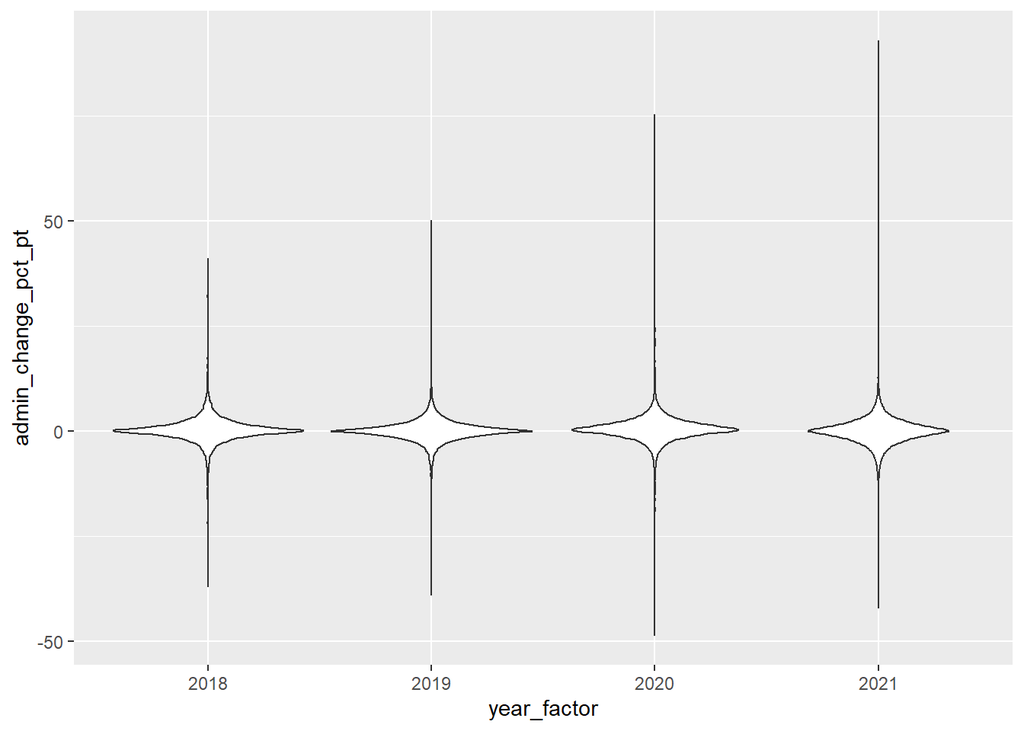

```r
plt <- ggplot(final.df, aes(x=year_factor, y=admin_change_pct_pt)) + geom_violin()
plt
```

Analysis: Large staffing star changes, +3 and +4 do appear more likely to be cases.

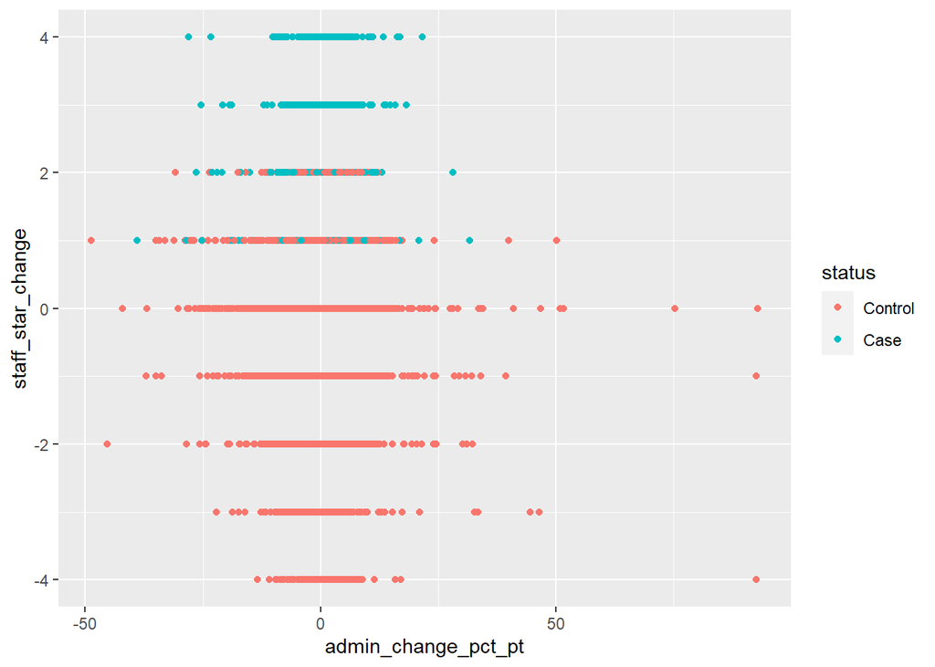

```r
plt <- ggplot(final.df, aes(x=admin_change_pct_pt, y=staff_star_change, color=status)) + geom_point()
plt
```

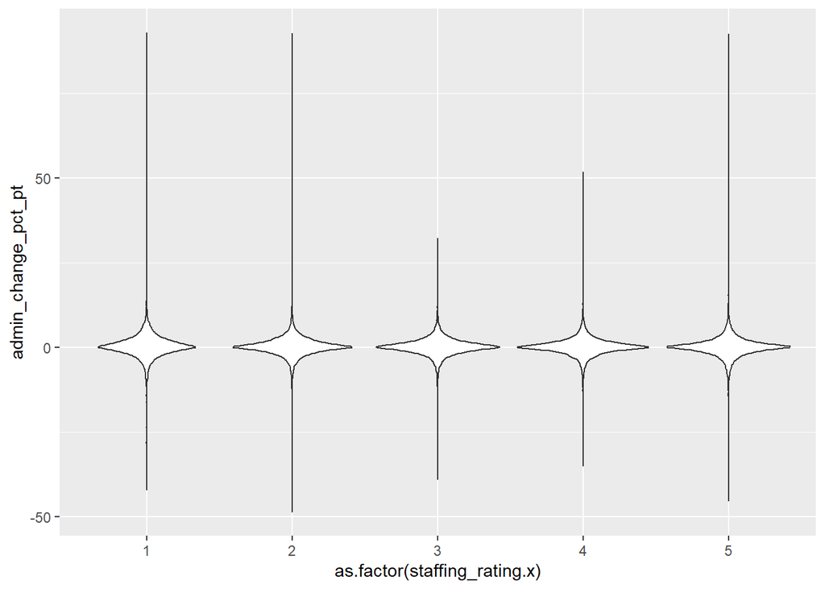

```r
plt <- ggplot(final.df, aes(x=as.factor(staffing_rating.x), y=admin_change_pct_pt)) + geom_violin()
plt
```

```r
select(final.df,
      c(staffing_rating.x, staff_star_change, status, year_factor),
      c(admin_change_pct_pt)
      ) %>% tbl_summary(by=year_factor)
```

| **Characteristic** | **2018**, N = 13,426<sup>1</sup> | **2019**, N = 14,156<sup>1</sup> | **2020**, N = 14,114<sup>1</sup> | **2021**, N = 13,111<sup>1</sup> |
| --- | --- | --- | --- | --- |
| staffing_rating.x |  |  |  |  |
| 1 | 1,555 (12%) | 2,081 (15%) | 1,621 (11%) | 1,372 (10%) |
| 2 | 1,926 (14%) | 3,458 (24%) | 3,653 (26%) | 2,534 (19%) |
| 3 | 4,057 (30%) | 4,032 (28%) | 4,074 (29%) | 3,457 (26%) |
| 4 | 4,332 (32%) | 3,067 (22%) | 3,146 (22%) | 3,340 (25%) |
| 5 | 1,556 (12%) | 1,518 (11%) | 1,620 (11%) | 2,408 (18%) |
| staff_star_change |  |  |  |  |
| -4 | 57 (0.4%) | 27 (0.2%) | 42 (0.3%) | 107 (0.8%) |
| -3 | 196 (1.5%) | 70 (0.5%) | 95 (0.7%) | 188 (1.4%) |
| -2 | 729 (5.4%) | 204 (1.4%) | 255 (1.8%) | 840 (6.4%) |
| -1 | 3,732 (28%) | 2,233 (16%) | 1,545 (11%) | 4,103 (31%) |
| 0 | 6,743 (50%) | 8,441 (60%) | 7,133 (51%) | 6,296 (48%) |
| 1 | 1,741 (13%) | 2,646 (19%) | 4,182 (30%) | 1,236 (9.4%) |
| 2 | 191 (1.4%) | 341 (2.4%) | 700 (5.0%) | 208 (1.6%) |
| 3 | 33 (0.2%) | 134 (0.9%) | 112 (0.8%) | 88 (0.7%) |
| 4 | 4 (<0.1%) | 60 (0.4%) | 50 (0.4%) | 45 (0.3%) |
| status |  |  |  |  |
| Control | 12,853 (96%) | 13,047 (92%) | 12,045 (85%) | 12,590 (96%) |
| Case | 573 (4.3%) | 1,109 (7.8%) | 2,069 (15%) | 521 (4.0%) |
| admin_change_pct_pt | 0.13 (-0.91, 1.32) | 0.00 (-1.04, 1.09) | 0.42 (-0.73, 1.68) | 0.00 (-1.44, 1.41) |

<sup>1</sup> n (%); Median (IQR)

```r
select(final.df,
      staffing_rating_seq, year_factor) %>% tbl_summary(by=year_factor)
```

| **Characteristic** | **2018**, N = 13,426<sup>1</sup> | **2019**, N = 14,156<sup>1</sup> | **2020**, N = 14,114<sup>1</sup> | **2021**, N = 13,111<sup>1</sup> |
| --- | --- | --- | --- | --- |
| staffing_rating_seq |  |  |  |  |
| 1 1 | 916 (6.8%) | 1,019 (7.2%) | 743 (5.3%) | 773 (5.9%) |
| 1 2 | 542 (4.0%) | 651 (4.6%) | 534 (3.8%) | 336 (2.6%) |
| 1 3 | 78 (0.6%) | 223 (1.6%) | 200 (1.4%) | 132 (1.0%) |
| 1 4 | 15 (0.1%) | 128 (0.9%) | 94 (0.7%) | 86 (0.7%) |
| 1 5 | 4 (<0.1%) | 60 (0.4%) | 50 (0.4%) | 45 (0.3%) |
| 2 1 | 379 (2.8%) | 422 (3.0%) | 407 (2.9%) | 674 (5.1%) |
| 2 2 | 1,064 (7.9%) | 2,169 (15%) | 1,632 (12%) | 1,424 (11%) |
| 2 3 | 398 (3.0%) | 785 (5.5%) | 1,298 (9.2%) | 388 (3.0%) |
| 2 4 | 67 (0.5%) | 76 (0.5%) | 298 (2.1%) | 46 (0.4%) |
| 2 5 | 18 (0.1%) | 6 (<0.1%) | 18 (0.1%) | 2 (<0.1%) |
| 3 1 | 390 (2.9%) | 108 (0.8%) | 164 (1.2%) | 328 (2.5%) |
| 3 2 | 1,379 (10%) | 767 (5.4%) | 524 (3.7%) | 1,329 (10%) |
| 3 3 | 1,819 (14%) | 2,318 (16%) | 1,777 (13%) | 1,458 (11%) |
| 3 4 | 423 (3.2%) | 797 (5.6%) | 1,407 (10.0%) | 312 (2.4%) |
| 3 5 | 46 (0.3%) | 42 (0.3%) | 202 (1.4%) | 30 (0.2%) |
| 4 1 | 192 (1.4%) | 67 (0.5%) | 92 (0.7%) | 152 (1.2%) |
| 4 2 | 292 (2.2%) | 74 (0.5%) | 66 (0.5%) | 328 (2.5%) |
| 4 3 | 1,517 (11%) | 706 (5.0%) | 431 (3.1%) | 1,304 (9.9%) |
| 4 4 | 1,953 (15%) | 1,807 (13%) | 1,614 (11%) | 1,356 (10%) |
| 4 5 | 378 (2.8%) | 413 (2.9%) | 943 (6.7%) | 200 (1.5%) |
| 5 1 | 57 (0.4%) | 27 (0.2%) | 42 (0.3%) | 107 (0.8%) |
| 5 2 | 4 (<0.1%) | 3 (<0.1%) | 3 (<0.1%) | 36 (0.3%) |
| 5 3 | 47 (0.4%) | 22 (0.2%) | 25 (0.2%) | 184 (1.4%) |
| 5 4 | 457 (3.4%) | 338 (2.4%) | 183 (1.3%) | 796 (6.1%) |
| 5 5 | 991 (7.4%) | 1,128 (8.0%) | 1,367 (9.7%) | 1,285 (9.8%) |

<sup>1</sup> n (%)

### Results

The model results suggest there is a relationship between having a top 5th percentile change in admin intensity and a jump in staffing ratings, increasing the odds ratio by a factor of 1.64. Interpretation of this statistic depends on an individual’s perception of the utility of “admin duties” :)

I have included controls: * Year level fixed effects to address failed independence assumption using panel data. Multiple observations of the same facility are obviously not independent. * For profit status (year 2) * Starting avg number of residents. This tends to stay relatively static. * Starting total nurse staffing hours * Change of ownership during assessed time period

```r
model <- glm(status ~ top_5_percentile_admin_change + for_profit + average_number_of_residents_per_day.x + adjusted_total_nurse_staffing_hours_per_resident_per_day.x + chow.y + year_factor, family=binomial, final.df)
summary(model)
```

```
##
## Call:
## glm(formula = status ~ top_5_percentile_admin_change + for_profit +
##     average_number_of_residents_per_day.x + adjusted_total_nurse_staffing_hours_per_resident_per_day.x +
##     chow.y + year_factor, family = binomial, data = final.df)
##
## Deviance Residuals:
##     Min       1Q   Median       3Q      Max
## -0.9343  -0.4429  -0.3268  -0.2736   2.9732
##
## Coefficients:
##                                                              Estimate
## (Intercept)                                                -1.6826164
## top_5_percentile_admin_changeTRUE                           0.4981498
## for_profitTRUE                                             -0.2370427
## average_number_of_residents_per_day.x                      -0.0035083
## adjusted_total_nurse_staffing_hours_per_resident_per_day.x -0.2624557
## chow.yY                                                    -0.2194502
##                                                            Std. Error z value
## (Intercept)                                                 0.1122856 -14.985
## top_5_percentile_admin_changeTRUE                           0.0624356   7.979
## for_profitTRUE                                              0.0371940  -6.373
## average_number_of_residents_per_day.x                       0.0003784  -9.272
## adjusted_total_nurse_staffing_hours_per_resident_per_day.x  0.0219895 -11.935
## chow.yY                                                     0.1249856  -1.756
##                                                            Pr(>|z|)
## (Intercept)                                                 < 2e-16 ***
## top_5_percentile_admin_changeTRUE                          1.48e-15 ***
## for_profitTRUE                                             1.85e-10 ***
## average_number_of_residents_per_day.x                       < 2e-16 ***
## adjusted_total_nurse_staffing_hours_per_resident_per_day.x  < 2e-16 ***
## chow.yY                                                      0.0791 .
##  [ reached getOption("max.print") -- omitted 3 rows ]
## ---
## Signif. codes:  0 '***' 0.001 '**' 0.01 '*' 0.05 '.' 0.1 ' ' 1
##
## (Dispersion parameter for binomial family taken to be 1)
##
##     Null deviance: 30004  on 54805  degrees of freedom
## Residual deviance: 28374  on 54797  degrees of freedom
##   (1 observation deleted due to missingness)
## AIC: 28392
##
## Number of Fisher Scoring iterations: 6
```

To steel-man both sides, an admin-proponent might argue that administration holds direct care staff accountable to higher quality, makes their work more efficient, and also participates in direct care when necessary. Therefore, increased admin intensity does not imply a reduction in attention to patients. Plus, if patients receive less attention, this should be visible in other quality scores going down!

An admin-skeptic might argue that admin time is principally focused on curating data related to public-facing quality scores. Except for claim-based measures, quality scores are largely derived from documentation. If admin duties primarily comprise parsing / cleaning up documentation, admin hours might enhance quality scores, without meaningfully improving direct patient care.